# Introduction au rapport

Le présent rapport se veut être l’analyse de différentes séries chronologiques. Plus précisément, il a pour but de trouver le modèle qui s’ajuste le plus exactement à nos échantillons de données. En bref, le travail consiste à séparer nos bases de données en un échantillon qui sert à trouver un modèle et en un échantillon qui sert à valider la précision du modèle retenu. Le travail est fait à partir de deux bases de données pour un total de cinq variables à modéliser. La première base de données, traitée au numéro 1, contient les données mensuelles du taux de change du dollar américain par rapport à l’euro de janvier 1999 à décembre 2016. La seconde base de données contient une série de statistiques de la , soit le nombre d’accidents automobiles avec dommages corporels, le nombre de personnes accidentées, le nombre de demandes d’indemnités et le coût total de l’indemnisation (en dollar constant 2015) pour les années 1978 à 2015 inclusivement. Ces données seront traîtées au numéro 2. Afin d’alléger la lecture du présent rapport, le code R est placé en annexe.

# Taux de change US/Euro

## Analyse primaire du jeu de données

Tout d’abord, nous observons, à la , la série chronologique du taux de change américain/européen depuis janvier 1999 jusqu’à décembre 2016. Les données ont été collectées de façon quotidienne pour ensuite être transformées en taux mensuelles.

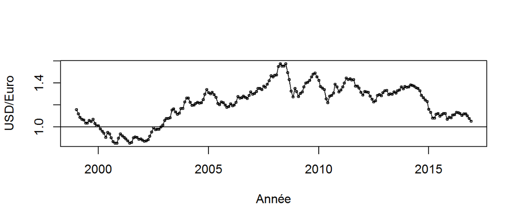

Grâce à une première analyse, on remarque sur le tableau de la fonction d’autocorrélation échantillonale qu’il y a une forte autocorrélation dans notre jeu de données et que celle-ci diminue lentement plus le lag augmente (voir ). On soupçonne donc fortement ce processus d’être non-stationnaire. Il n’est pas nécessaire de tracer le graphique de la fonction d’autocorrélation partielle puisqu’on doit d’abord stationnariser notre processus avant de réellement débuter notre analyse.

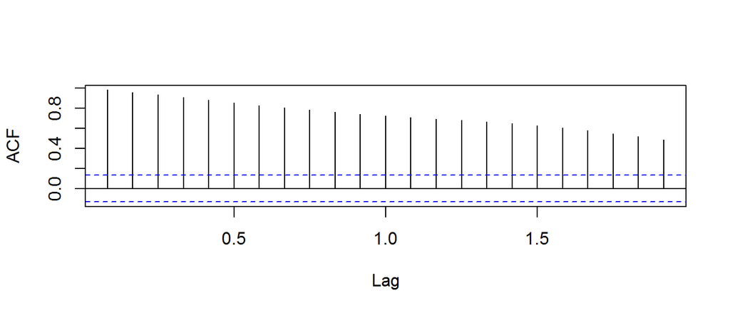

## Test de stationnarité

Le test de stationnarité de Dickey-Fuller est alors effectué sur notre base de données. On remarque que, pour un ordre $k=2$ de processus auto-autoregressif tel que proposé par la fonction de , notre processus est non stationnaire à un niveau de confiance de $5$% avec une très forte de 91.33%. On vérifie alors si une transformée Box-Cox est apppropriée à notre modèle avant de tester la stationnarité d’une première différenciation.

## Transformation des données

Étant donné que les données sont positives, il est possible d’utiliser la transformée de Box-Cox afin de stabiliser notre processus. On rappelle que la famille des fonctions de puissance est définie de la façon suivante:

$$\begin{aligned}
g(x) = \frac{x^{\lambda}-1}{\lambda} \times 1_{\{\lambda \neq 0 \}} + \text{ln}(x) \times 1_{\{\lambda = 0 \}}
\end{aligned}$$

$\lambda$ est donc déterminé en maximisant la fonction de log-vraisemblance de nos données fournie à la .

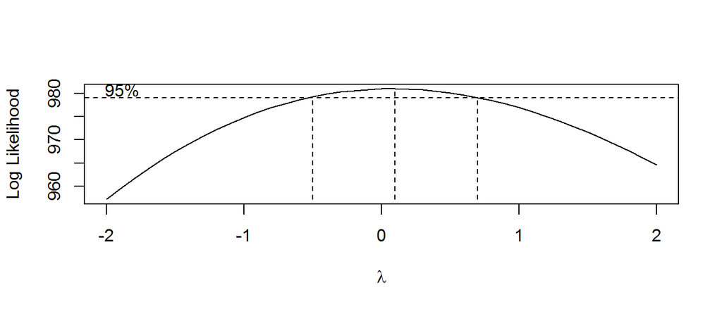

Fonction du logarithme de vraissemblance de la transformée de Box-Cox de la série chronologique du taux de change US/Euro.

On constate que $\lambda = 0.1$ semble être l’estimé MLE situé au centre de l’intervalle de confiance 95%, soit $]-0.5, 0.7[$. Puisque $\lambda = 0$ est dans notre intervale de confiance, cette valeur du paramètre est également à considérer. Dans le cas où le processus serait à différencier une seule fois, la transformation logarithmique est particuliairement intéressante puisqu’elle permet de modéliser non pas le «prix» du taux de change, mais sont rendement comme il est usage de le faire dans le cas d’outils financiers. En effet, soit $Y_t$ le prix d’un outil financier au temps $t$, le modèle logarithmique modélise le rendement de la façon suivante[^1]

$$Y_t=Y_{t-1}e^{X}$$
où , le rendement continu mensuel, est la variable aléatoire à modéliser. Ainsi, suite à une première différenciation de notre modèle logarithmique, on obtient direction ce rendement. Soit,
$$log\left(\frac{Y_t}{Y_{t-1}}\right)=X$$
On conserve alors cette transformation à condition que la première différenciation de notre processus soit stationnaire. Le graphique de cette transformation est affiché à la .

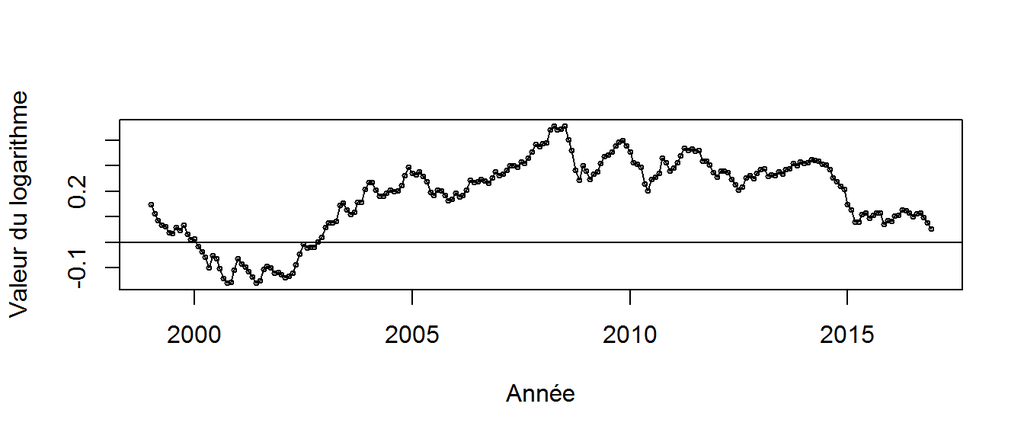

Suite à une première différenciation, on effectue à nouveau le test augmenté de Dickey-Fuller. Avec un processus autorégressif d’ordre 1 tel que suggéré par la fonction $ar$, on remarque cette fois qu’on ne peut rejetter pas l’hypothèse de stationnarité avec un p-value inférieur à 1%. Ainsi, tel que mentionné précédement, la transformation logarithmique est conservée. Le graphique de la première différenciation du logarithme de la série chronologique à l’étude se trouve ci-dessous à la .

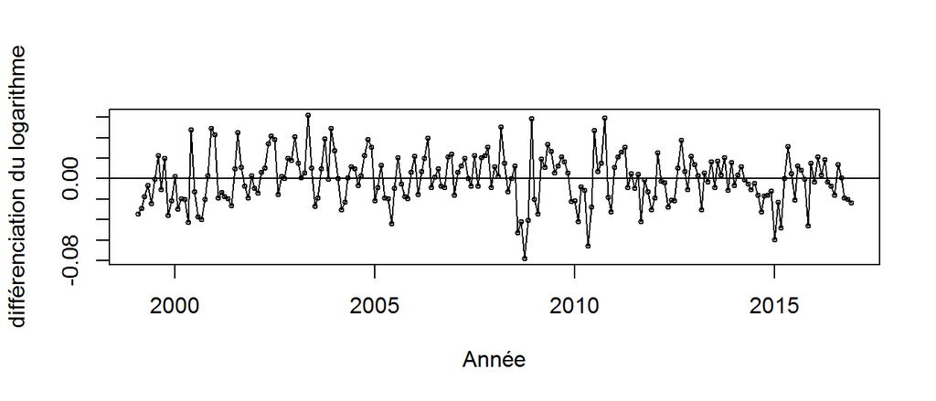

## Identification du modèle

Maintenant que la série est stationnaire, on peut en identifier le modèle. La première différenciation du logarithme du taux de change US/Euro est dorénavent notre modèle de base. On fera ainsi référence à ce modèle par défaut. On observe les fonctions d’autocorrélation et d’autocorrélation partielle affichées aux et de cette série. On remarque que la fonction d’autocorrélation suggère fortement un modèle à moyenne mobile d’ordre 1, soit IMA(1,1) pour notre modèle tansformé alors que la fonction d’autocorrélation partielle suggère un modèle autorégressif d’ordre 1, soit ARI(1,1). On testera alors également le modèle ARIMA(1,1,1) qui est suggéré par la combinaison de ces graphiques.

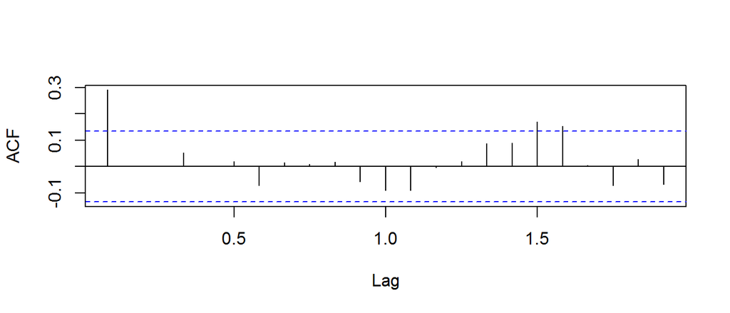

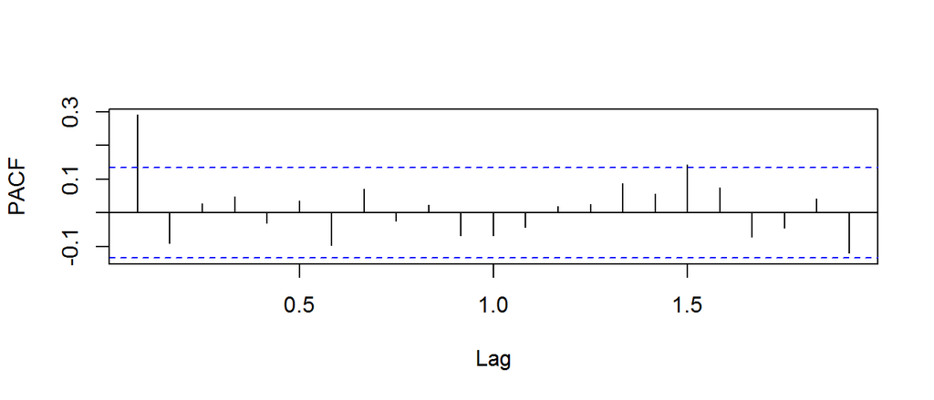

On observe ensuite la fonction d’autocorrélation étendue afin de voir si ce test à un autre modèle à proposer. Le tableau de la fonction EACF est à la . On observe d’abord de ce tableau que le modèle IMA(1,1) est suggéré pour la différenciation de notre modèle transformé initial. On peut également chercher à savoir si la valeur du $o$ en ARMA(0,1) et du $x$ en ARMA(1,1) sont significativement différent de leur valeurs inverses ($x$ pour le $o$ et vice versa), sans quoi le modèle ARIMA(1,1,1) serait également suggeré par le tableau EACF. Cependant, comme il fut déjà décidé d’évaluer la pertinance du modèle ARIMA(1,1,1) suite à l’analyse des fonction d’autocorrélation et d’autocorrélation partielle, il n’est pas nécessaire de tester la pertinance de ce modèle selon le EACF.

```
## AR/MA
##   0 1 2 3 4 5 6 7 8 9 10 11 12 13
## 0 x o o o o o o o o o o  o  o  o
## 1 x x o o o o o o o o o  o  o  o
## 2 x o o o o o o o o o o  o  o  o
## 3 x x x x o o o o o o o  o  o  o
## 4 x x o x o o o o o o o  o  o  o
## 5 x o x x o o o o o o o  o  o  o
## 6 x x x x o o o o o o o  o  o  o
## 7 x x x x x x o o o o o  o  o  o
```

Le dernier test effectué pour ajuster un modèle à notre série chronologique est le test du BIC. Le tableau du BIC (tracé à la ) propose un modèle ARI(1,1). L’ordre maximal de moyenne mobile pour ce test a été établi à 1, sans quoi la fonction permettant de tracer le tableau du BIC retourne des avertissements de forte dépendance linéaire entre les paramètres.

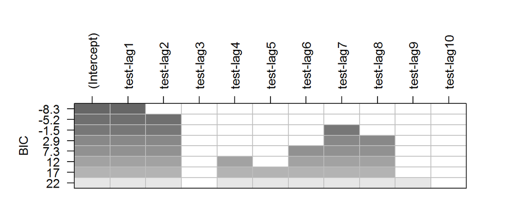

$$\begin{tabular}{| l | r |}
\hline
\multicolumn{2}{|c|}{Résumé}\\
\hline
Tests et tableaux & Modèles suggérés \\ \hline \hline
ACF & IMA(1,1) \\
& ARIMA(1,1,1) \\ \hline
PACF & ARI(1,1) \\
& ARIMA(1,1,1)\\ \hline
EACF & IMA(1,1) \\ \hline
BIC & ARI(1,1) \\
\hline
\end{tabular}$$

On teste alors respectivement les modèles ARI(1,1), IMA(1,1) et ARIMA(1,1,1) suivants

$$\begin{aligned}
W_t-\mu &= \phi (W_{t-1}-\mu) + e_t \qquad \qquad \qquad &(1)\\
W_t -\mu&= e_t-\theta e_{t-1} \qquad \qquad \qquad &(2)\\
W_t- \mu&= \phi (W_{t-1}-\mu) + e_t-\theta e_{t-1} \qquad \qquad \qquad &(3)\\
\end{aligned}$$
Où
$$W_t=\nabla \text{ln}(Y_t)$$
et $e_t$ est un bruit blanc et $\mu$ la moyenne de la série chronologique non-centrée. Il est ici important de noter que les paramètres estimés $\hat{\theta}$ et $\hat{\phi}$ ne seront pas les mêmes dans les trois modèles et devront donc être estimés pour chacun d’entre eux.

## Estimation des paramètres des différents modèles et tests de résidus

On estime alors les valeurs des différents paramètres selon la méthode du maximum de vraisemblance à l’aide de la fonction $arima$. Les résultats se trouvent à la .

$$\begin{tabular}{| l c |c|c| r |}
\hline
Modèles & Paramètres & Valeurs estimés & AIC & Logarithme du max \\
& & & & de vraisemblance \\ \hline \hline
IMA(1,1) & $\mu$ & 0 & $-1010$ & $506$\\
& $\theta$ & $0.3118$& &\\ \hline
IMA(1,2) & $\mu$ & 0 & $-1008$ & $506$\\
& $\theta_1$ & $0.3207$& &\\
& $\theta_2$ & $0.0207$& &\\ \hline
ARI(1,1) & $\mu$ & 0& $-1009$ &$505$\\
& $\phi$ & $0.2933$& &\\ \hline
ARIMA(1,1,1) & $\mu$ & 0& $-1008$ &$506$\\
& $\theta$ & 0.2635& &\\
& $\phi$ & 0.0557& &\\
\hline
\end{tabular}$$
Tableau des valeurs estimées des différents coefficients obtenus de la fonction pour les trois modèles à l’étude du logarithme du taux de change US/Euro.

On peut alors faire l’analyse de nos résidus pour faire notre choix parmi nos trois modèles. Les résidus standardisés de ces trois modèles sont tracés à la . On remarque d’abord que ces trois courbes se superposent et ne peuvent donc pas être utilisées pour sélectionner un modèle. De plus, on remarque de ce graphique que les valeurs de résidus supérieures à 2 en valeur absolue sont relativement fréquentes ce qui nous poussent à questionner la théorie selon laquelle les résidus suivent une loi normale. En effet, dans le cas des résidus normaux, les valeurs supérieurs à 2 en valeur absolue ne devrait apparaître qu’environ 2.28% du temps. La fréquence observée est nettement supérieur.

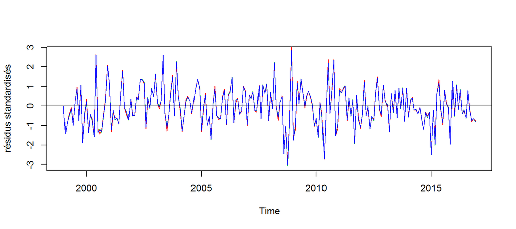

Superposition des graphiques des résidus standardisés des modèles ARI(1,1), IMA(1,1) et ARIMA(1,1,1) du logarithme du taux de change US/Euro.

On regarde ensuite les histogrammes et les graphiques QQ aux et des résidus. On remarque que les trois histogrammes semblent tracer avec efficacité la cloche de la loi normal. De plus, on remarque des trois graphiques QQ, que les résidus observés sont en tout point simiaire à leur valeur théorique en cas de normalité. Ces deux test semblent donc justifier la distribution normale des résidus de nos trois modèles.

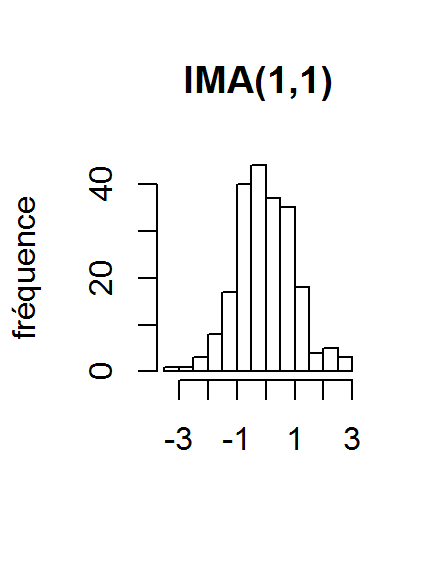

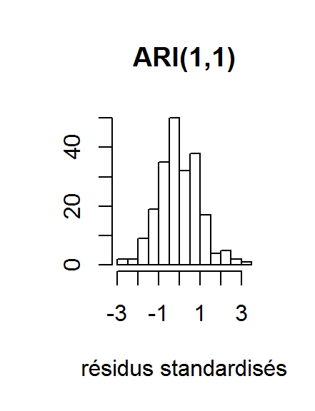

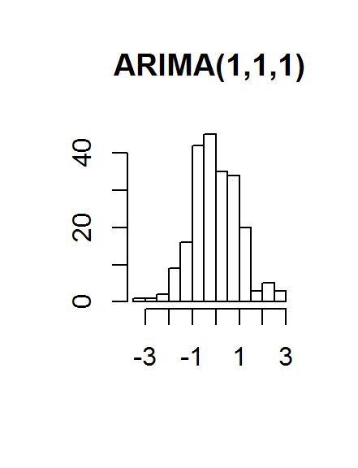

Histogramme des résidus standardisés des modèles étuidés du logarithme du taux de change US/Euro.

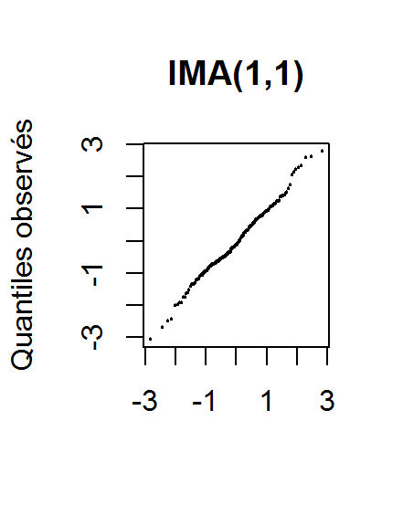

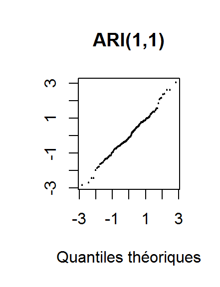

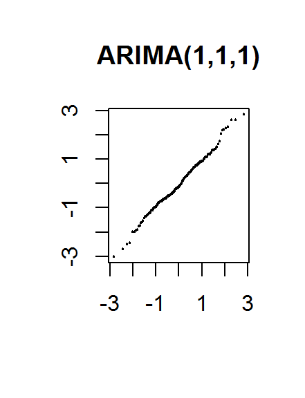

Graphiques QQ des modèles étuidés du logarithme du taux de change US/Euro.

On effectue alors, pour tenter de départager nos modèles, le test de Shapiro-Wilk évaluant le dégré de corrélation entre les quantiles des résidus standardisés et la loi normale standard. L’hypothèse nulle étant que la distribution des résidus suit une loi normale On confirme, avec des p-values respectives de 0.3247, 0.2846 et 0.3051, que les résidus engendrés par les modèles IMA(1,1), ARI(1,1) et ARIMA(1,1,1) sont tous normalement distribués pour un test à un niveau de confiance $\alpha$ de 5%. On cherche également un modèle dont les résidus sont indépendants, sans quoi on ne retrouve pas un bruit blanc. On effectue alors le run-test sur nos modèles pour tester l’indépendance entre les résidus. Comme l’hypothèse nulle est que les résidus sont indépendants, on conclut à un niveau de confiane de $\alpha=5$% qu’on ne peut rejetter l’hypothèse nulle si la p-value est supérieur à 5%. On trouve alors, pour les modèles IMA(1,1), ARI(1,1) et ARIMA(1,1,1) des valeurs respectives de 0.399, 0.81 et 0.793 pour les p-value de leur run-tests. Ainsi, aucun de ces modèles rejettent l’hypothèse de normalité. On effectue un dernier test sur nos modèles afin de les départager. Le test de Ljung-Box à pour hypothèse nul que le modèle testé sur notre série chronologique est approprié. On remarque des à que les p-values des trois modèle ne permettent pas de rejetter l’hypothèse nulle. Les trois modèles sont donc, selon ce test, appropriés pour modéliser la série chronologique à l’étude.

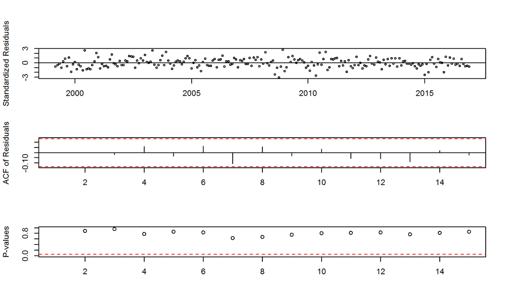

Graphiques des résidus standardisés, de l’autocorrélation des résidus et des p-values du test de Ljung-Box du modèle IMA(1,1) pour le logarithme du taux de change US/Euro.

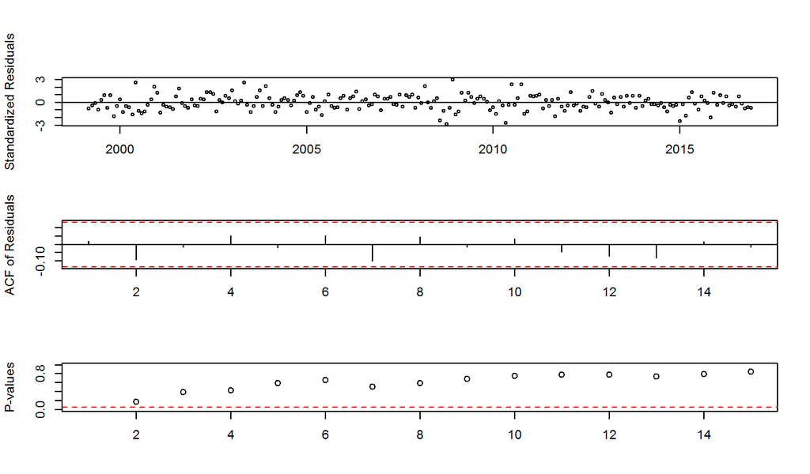

Graphiques des résidus standardisés, de l’autocorrélation des résidus et des p-values du test de Ljung-Box du modèle ARI(1,1) pour le logarithme du taux de change US/Euro.

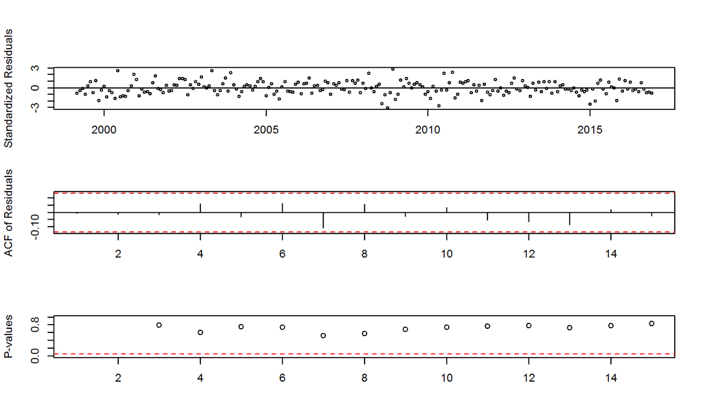

Graphiques des résidus standardisés, de l’autocorrélation des résidus et des p-values du test de Ljung-Box du modèle ARIMA(1,1,1) pour le logarithme du taux de change US/Euro.

## Prédictions

On peut alors effectuer les prédictions des taux de changes US/Euro des mois de l’année 2017 grâce au modèle suivant

$$\nabla \text{ln} (Y_t)=e_t-0.3118 e_{t-1}$$
Il est important de noter que, puisqu’une transformation logarithmique a été effectuée sur les données du taux de change US/Euro, le prédicteur de $Y_t$, $\hat{Y}_t(l)$, sera tel que

$$\hat{Y}_t(l)=\text{exp}\left(\hat{Z}_t(l)+\frac{\text{Var}[e_t(l)]}{2}\right)$$
Où $\hat{Z}_t(l)$ est le prédicteur de $Z_t$ défini tel que $Z_t=\text{ln}Y_t$. Le graphique des valeurs prédites se trouvent aux graphiques et . On remarque d’abord du second graphique que toutes les valeurs du taux de change US/Euro observées en 2017 se trouvent à l’intérieur de l’intervalle de confiance de nos prédictions. L’intervalle de confiance est fait à un niveau de confiance de 95%.

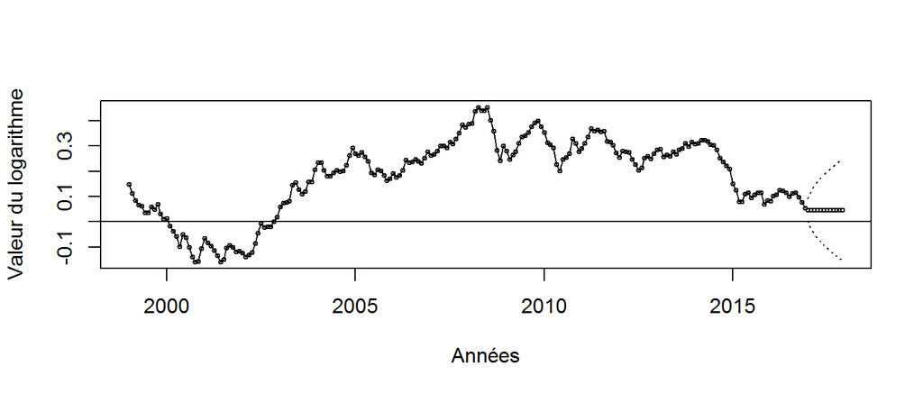

Logarithme du taux de change US/Euro mensuelle de janvier 1999 à décembre 2016 avec prédictions pour l’année 2017 et intervalle de confiance à 95%.

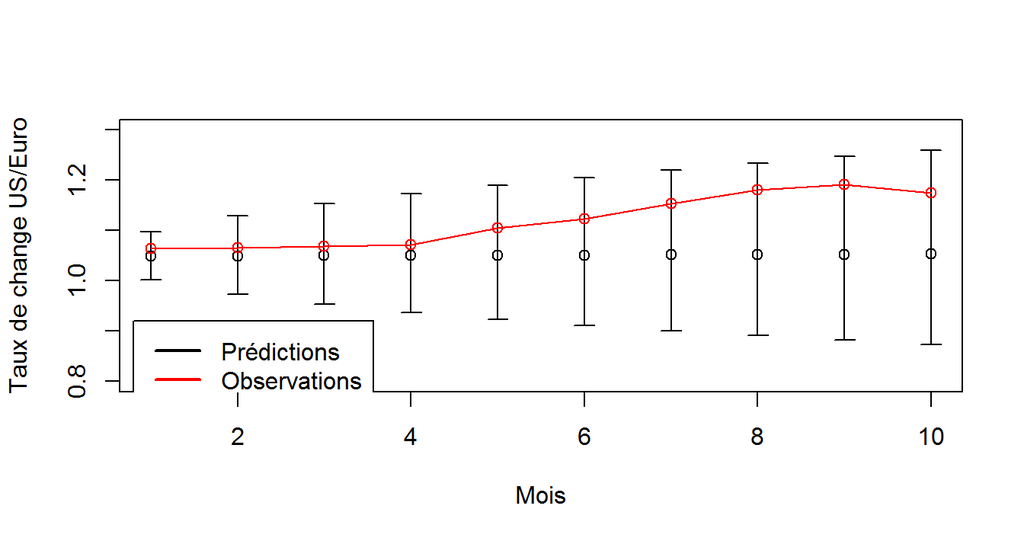

Comparaison entre les valeurs prédites du taux de change US/Euro grâce au modèle IMA(1,1) avec intervalle de confiance et les valeurs observerées pour l’année 2017.

On retrouve également les valeurs des prédictions du taux de change US/Euro pour les 10 premiers mois de l’année 2017 dans le tableau suivant

| Mois | $Y_{t+l}$ | $\hat Y_t(l)$ | $\hat e_t(l)$ | $\sqrt{Var(\hat Y_t(l))}$ | Borne inf. de prédiction | Borne sup. de prédiction |
| --- | --- | --- | --- | --- | --- | --- |
| Janvier | 1.0635 | 1.0487 | 0.0148 | 0.023 | 1.0023 | 1.0968 |
| Février | 1.065 | 1.0492 | 0.0158 | 0.0379 | 0.9734 | 1.1293 |
| Mars | 1.0691 | 1.0497 | 0.0194 | 0.0484 | 0.9535 | 1.1528 |
| Avril | 1.0714 | 1.0502 | 0.0212 | 0.057 | 0.9375 | 1.1725 |
| Mai | 1.105 | 1.0506 | 0.0544 | 0.0645 | 0.9239 | 1.1898 |
| Juin | 1.1233 | 1.0511 | 0.0722 | 0.0712 | 0.9119 | 1.2055 |
| Juillet | 1.153 | 1.0516 | 0.1014 | 0.0773 | 0.901 | 1.22 |
| Août | 1.1813 | 1.0521 | 0.1292 | 0.083 | 0.891 | 1.2337 |
| Septembre | 1.1913 | 1.0525 | 0.1388 | 0.0883 | 0.8818 | 1.2466 |
| Octobre | 1.174 | 1.053 | 0.121 | 0.0933 | 0.8732 | 1.2588 |

où $\hat e_t(l) = Y_{t+l} - \hat Y_{t}(l)$ représente l’erreur de prédiction.

## Conclusion

En observant le graphique et la valeur de nos prédictions, on observe que celles-ci semblent converger vers une valeur bien précise. Cependant, plus on tente de prédire pour des périodes éloignées, plus notre intervalle de confiance grandit et plus notre incertitude devient élevée.

# SAAQ

## Analyse primaire du jeu de données

Tout d’abord, on fait l’analyse du jeu de données en lien avec la SAAQ. On étudie les valeurs de nos quatres séries chronologiques depuis 1978 jusqu’en 2015. Cela comprend la série du nombre d’accidents avec dommages corporels (NAADC), du nombre de personnes accidentés (NPA), du nombre de demandes d’indemnités (NDI), et du coût total de l’indemnisation en millions de dollars, et en dollars constants 2015 (CTI), le tout sur une base annuelle. Puisque la banque de données semble comporter certaines valeurs aberrantes, on applique des changements à ces données grâce à la commande *tsoutliers*. Les nouvelles séries chronologiques sont affichées ci-dessous dans la

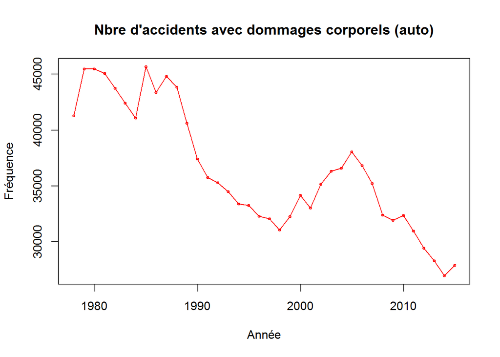

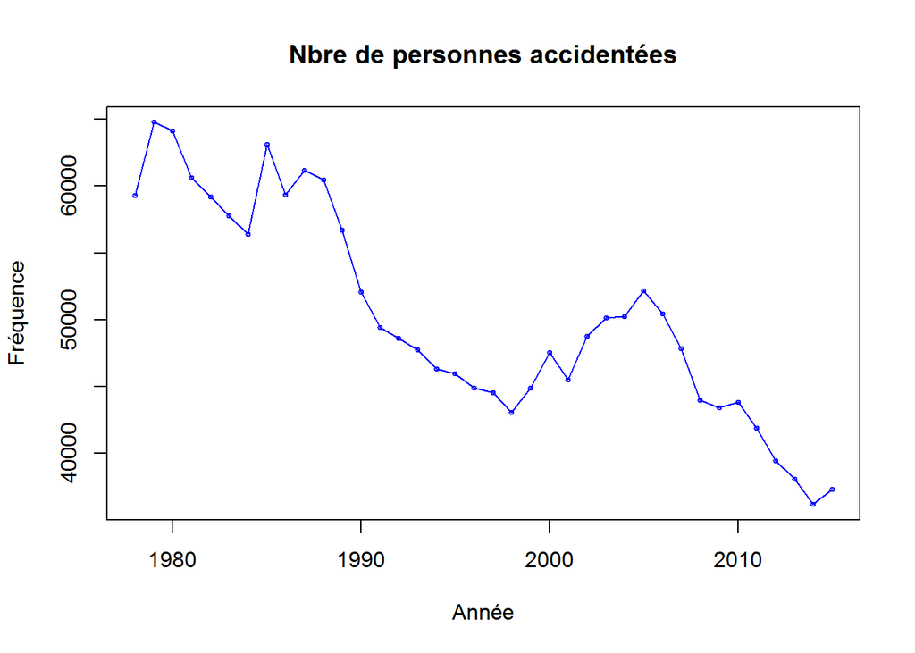

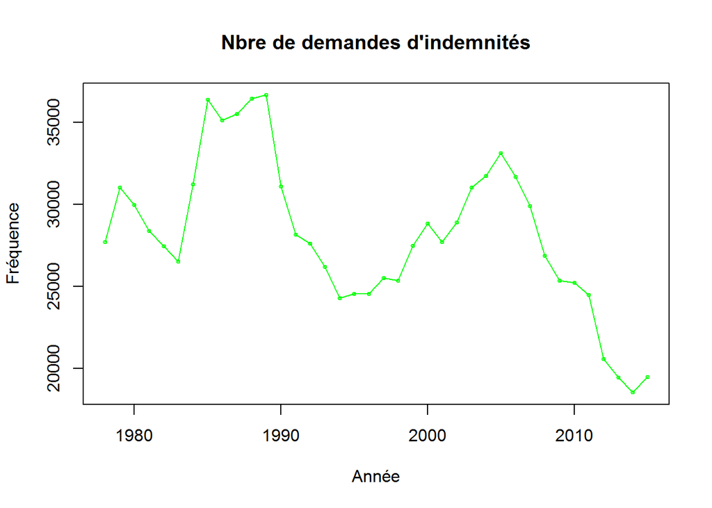

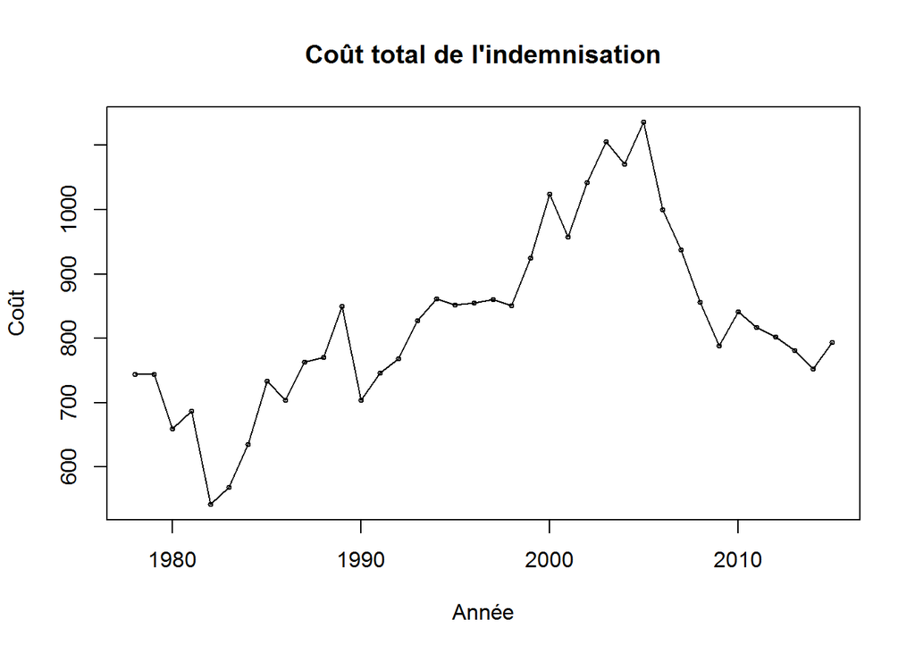

Graphiques des différentes séries chronologiques après modification des données aberrantes depuis 1978 jusqu’en 2015 (NAADC en rouge, NPA en bleu, NDI en vert et CTI en noir).

## Test de stationnarité

L’analyse débute encore une fois par les tests de stationnarités. On commence ainsi par effectuer le test de Dickey-Fuller sur notre modèle pour tester ça stationnarité. Le test a été expliqué au numéro précédent. Nous obtenons les résultats suivants

| Série chrono. | coeff. *k* dans AR(*k*) | p-value | Stationnarité |
| --- | --- | --- | --- |
| NAADC | 2 | 0.4802 | Non |
| NPA | 2 | 0.499 | Non |
| NDI | 2 | 0.5238 | Non |
| CTI | 1 | 0.8737 | Non |

Étant donné que chacune des séries chronologiques a une p-value > 5%, on ne peut pas rejeter l’hypothèse nulle du test qui stipule que la série est non-stationnaire. Une première différenciation s’impose. Cependant, il faudrait d’abord observer si une transformation est approprié pour stabiliser la variance. On effectue ainsi la transformation de Box-Cox.

## Transformation des données

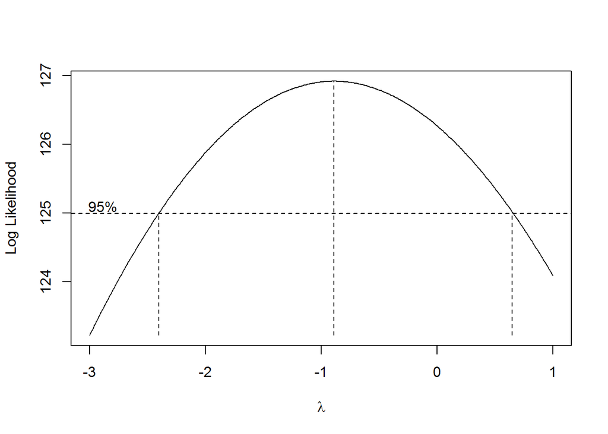

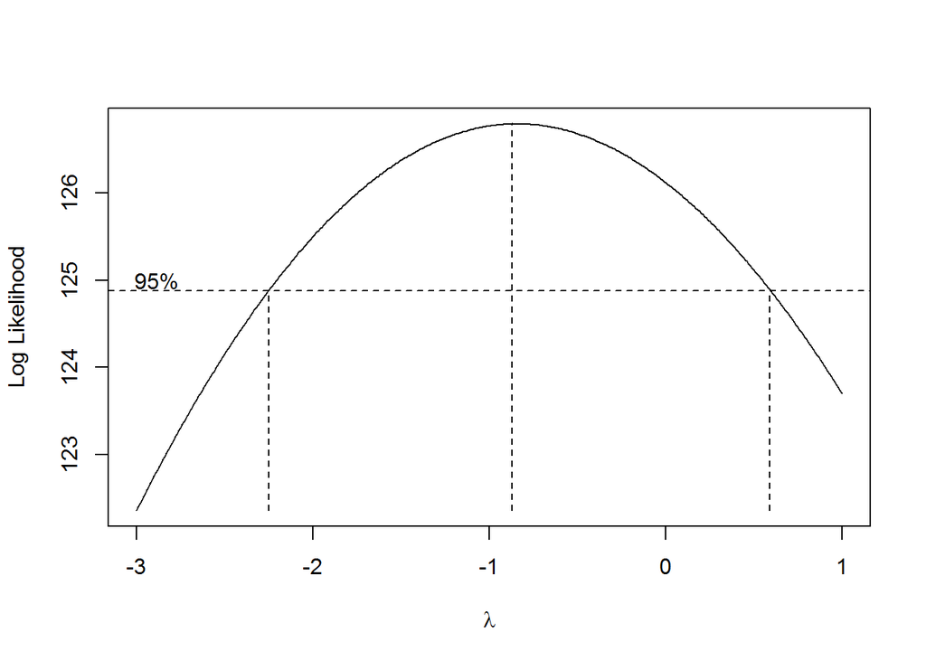

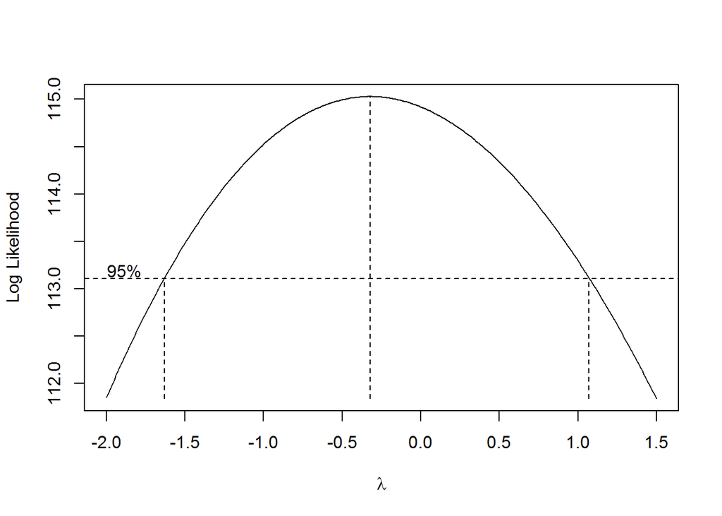

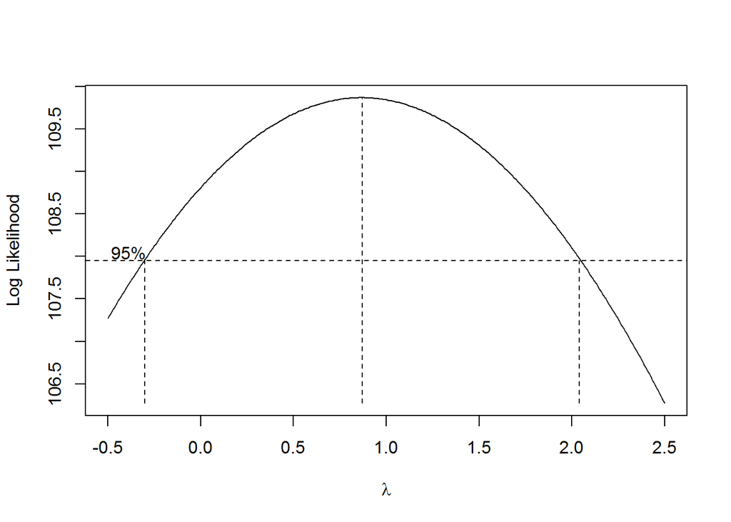

On peut donc observer grâce au maximum de vraisemblance que les valeurs de $\lambda$ sont approximativement -1, -1, 0 et 1 pour les séries NAADC, NPA, NDI et CTI respectivement. On note qu’il n’y a donc pas de transformation a appliquer à la série CTI.

On peut alors, tester la stationnarité de la première différenciation des données transformées encore à l’aide du test de Dikey-Fuller. Ce test renvoie cette fois les valeurs suivantes

| Série chrono. | coeff. *k* dans AR(*k*) | p-value | Stationnarité |
| --- | --- | --- | --- |
| NAADC | 0 | 0.01 | Oui |
| NPA | 0 | 0.01 | Oui |
| NDI | 1 | 0.0323 | Oui |
| CTI | 0 | 0.01 | Oui |

On remarque cette fois que la p-value de chaque modèle est inférieure à 5%, ce qui nous permet d’affirmer la stationnarité de ceux-ci. On peut maintenant passer à l’étape du choix du modèle.

## Identification du modèle

On affiche les graphiques de nos nouvelles séries chronologiques ci-dessous après avoir apporté la transformation et la différenciation à chacun

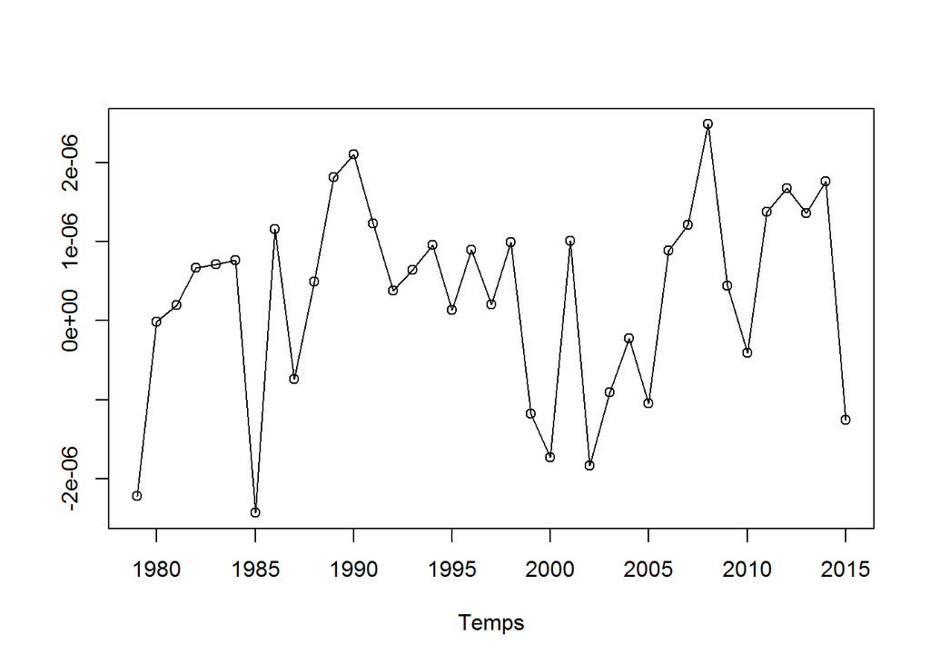

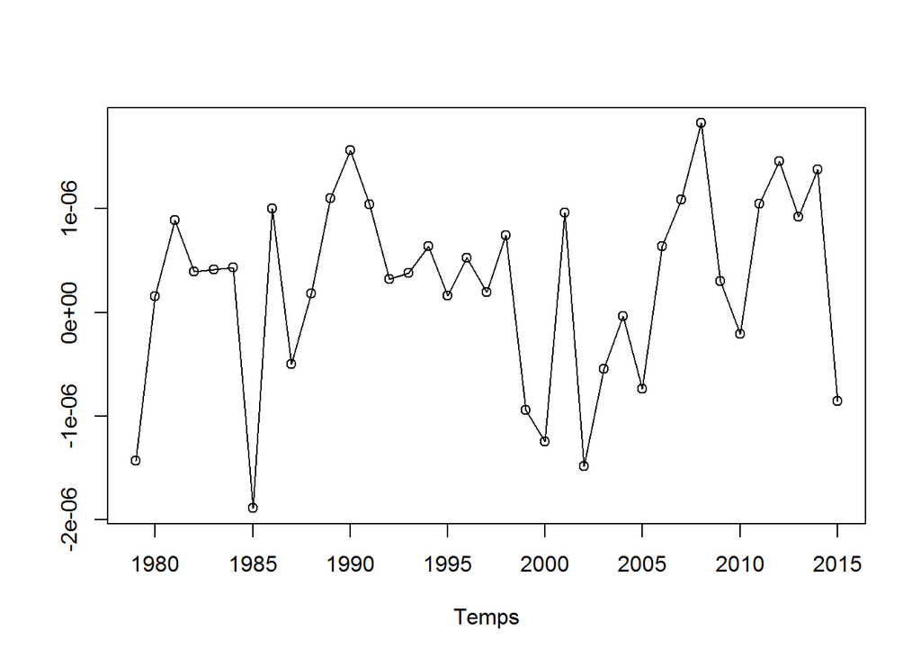

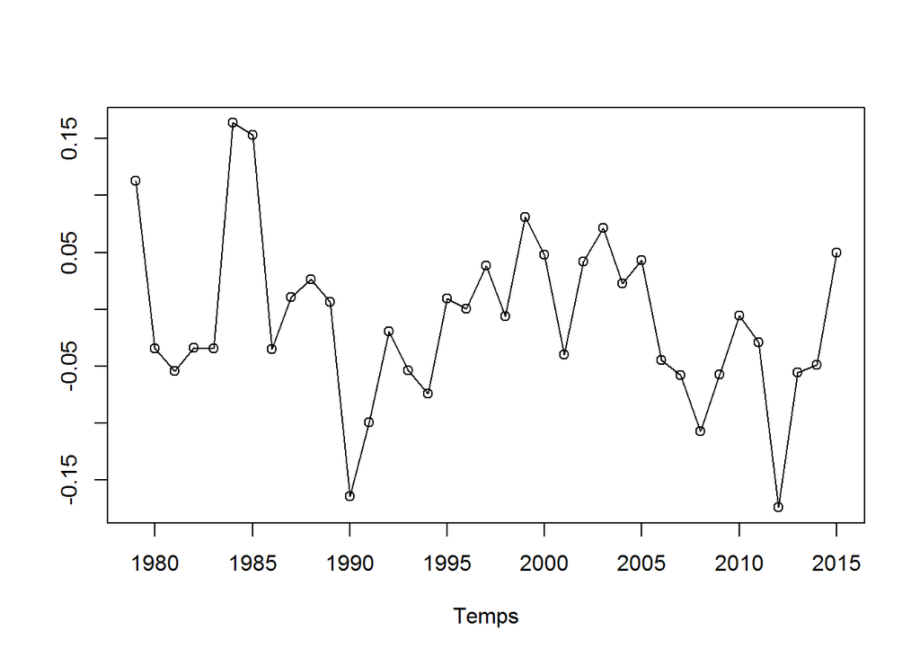